# Project 3

Jake Brophy,Wooin Lee,Frederick Kiaie,Zakary Lang

11/29/2021

UID: Jake Brophy: 305-088-618 Wooin Lee: 304-488-514 Frederick Kiaie: 105-113-992 Zakary Lang: 904-928-727

Setup:

```r
library(plm)
library(knitr)
library(broom)
library(tidyverse)
library(stargazer)
library(lmtest)
```

```r
library(wooldridge)
library(gplots)
data('rental')
attach(rental)
library(corrplot)
library(MASS)
rental_p <- pdata.frame(rental, index = c('city','year'))
```

part I

Question 1:

Our objective is to understand the features that impact our dependent variable, rent (we used the variable, lrent, which is the log of rent) across college towns (N) for multiple time periods 1980 or 1990 (T), and we are interested in understanding if one of the features, i.e. student population, is a significant factor for rent.

Data explanation: Data for 64 “college towns” from the 1980 and 1990 United States censuses. • city: city label, 1 to 64 • year: 80 or 90 • lenroll: log(enroll) • lpop: log(pop) • lrent: log(rent) • ltothsg: log(tothsg) • lrnthsg: log(rnthsg) • lavginc: log(avginc) • pctstu: percent of population students

Question2:

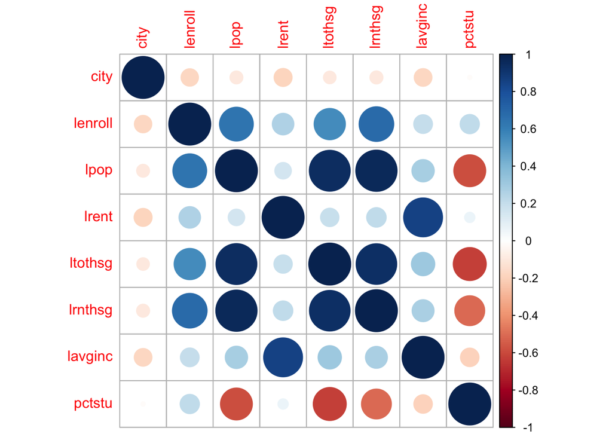

```r
rental2 <- subset(rental, select = c(city, lenroll, lpop, lrent, ltothsg,
                                      lrnthsg, lavginc, pctstu))

cor <- cor(rental2)
corrplot(cor)
```

```r
library(reshape)
meltData2 <- melt(rental2)
```

```
## Using  as id variables
```

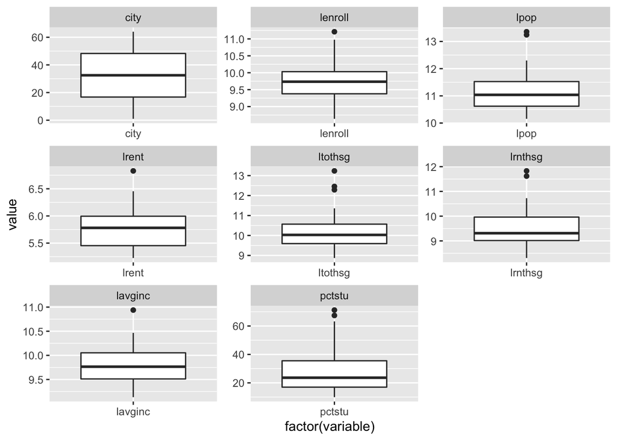

```r
p <- ggplot(meltData2, aes(factor(variable), value))
p + geom_boxplot() + facet_wrap(~variable, scale="free")
```

From the correlation plot, we can see that the variable most correlated with rent is average income which makes intuitive economic sense, followed by the number of students enrolled in a college in a city.

From the boxplots of our variables of interest, we can see that our variables have relatively few outliers. Notable exceptions include the log of total occupied housing units, lag of total renter occupied housing units, and percentage of population that is students.

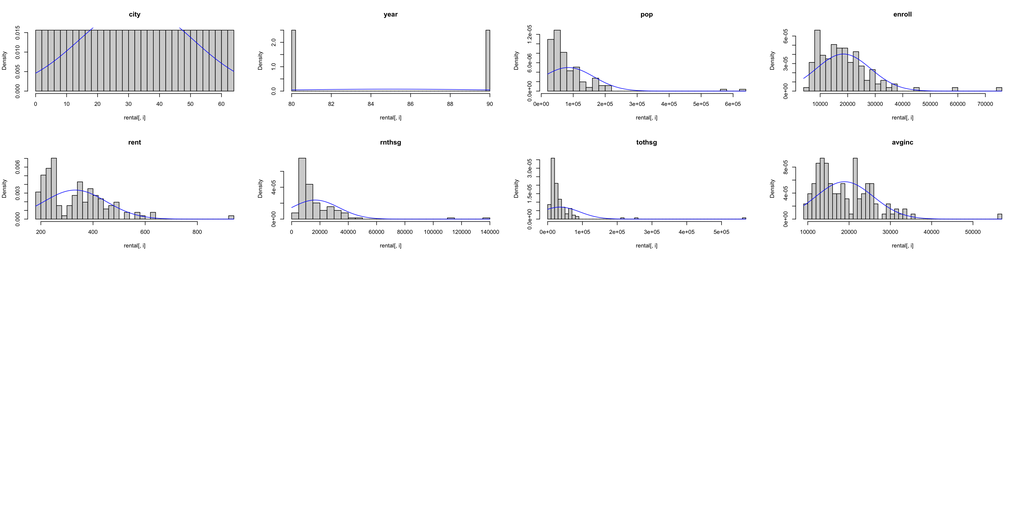

```r
par(mfrow = c(4,4))
for(i in 1:8) {
  fit <- fitdistr(rental[,i], densfun="normal")
  hist(rental[,i], pch=30, breaks=40, prob = TRUE, main = names(rental)[i])
  curve(dnorm(x, fit$estimate[1], fit$estimate[2]), col="blue", add=T)
}
```

We can see that the number of college students enrolled in a city is on average between 10,000 and 25,000 with some outliers having as many as 70,000

Rent is more irregularly distributed, with most cities having rent that falls between 200 and 400 dollars

Per capita income is also irregularly distributed, with most cities having income between $10,000 and $20,000

Question 3:

```
##
##  F test for individual effects
##
## data:  lrent ~ year + lpop + lavginc + pctstu + lenroll + ltothsg +  ...
## F = 6.5855, df1 = 63, df2 = 57, p-value = 9.114e-12
## alternative hypothesis: significant effects
```

```
##
##  Hausman Test
##
## data:  lrent ~ year + lpop + lavginc + pctstu + lenroll + ltothsg +  ...
## chisq = 61.955, df = 7, p-value = 6.137e-11
## alternative hypothesis: one model is inconsistent
```

We came to this conclusion using the pFtest() function which tests for individual or time differences, and given a p-value of 9.114e-12 we reject the null hypothesis of no individual or time effects and decide fixed effects are present.

Next, between choosing fixed effects (FE) and random effects models (RE), we ran the Hausman Test and since p-value is less than 0.05, we reject H0 (“RE is better than FE”) and choose the Fixed Effects Model instead.

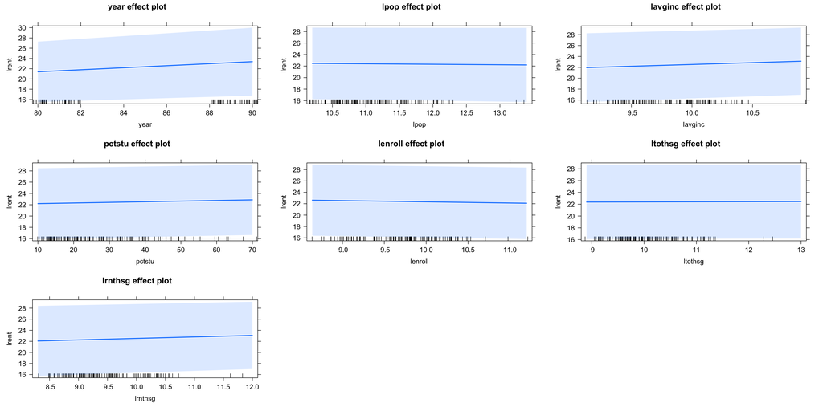

```r
library('effects')
plot(allEffects(pooled))
```

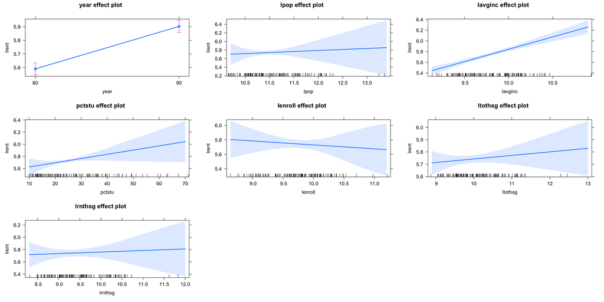

```r
plot(allEffects(re))
```

From the effects plot, we can see that both for both the pooled and random effects model, the strongest effect on rent came from year and average income which makes sense since properties become more expensive over time and in areas with a high average income. In general, the direction of the effects stays consistent in both models, but in the random effects model we can much more clearly see the effect than in the pooled model.

Part II

Question 1:

The model consisted of data on the S&P 500 that was obtained from Yahoo Finance. The variables of interest were, Year: The year that the observation was recorded, Lag1: Percentage return for previous day, Lag2: Percentage return for 2 days previous, Lag3: Percentage return for 3 days previous, Lag4: Percentage return for 4 days previous, Lag5: Percentage return for 5 days previous, Volume: Volume of shares traded (number of daily shares traded in billions), and Direction: A factor with levels Down and Up indicating whether the market had a positive or negative return on a given day. The model attempted to predict variable Direction.

Question 2:

```r
require(ISLR)
names(Smarket)
```

```
## [1] "Year"      "Lag1"      "Lag2"      "Lag3"      "Lag4"      "Lag5"
## [7] "Volume"    "Today"     "Direction"
```

```r
data("Smarket")
summary(Smarket)
```

```
##       Year           Lag1                Lag2                Lag3
##  Min.   :2001   Min.   :-4.922000   Min.   :-4.922000   Min.   :-4.922000
##  1st Qu.:2002   1st Qu.:-0.639500   1st Qu.:-0.639500   1st Qu.:-0.640000
##  Median :2003   Median : 0.039000   Median : 0.039000   Median : 0.038500
##  Mean   :2003   Mean   : 0.003834   Mean   : 0.003919   Mean   : 0.001716
##  3rd Qu.:2004   3rd Qu.: 0.596750   3rd Qu.: 0.596750   3rd Qu.: 0.596750
##  Max.   :2005   Max.   : 5.733000   Max.   : 5.733000   Max.   : 5.733000
##       Lag4                Lag5              Volume           Today
##  Min.   :-4.922000   Min.   :-4.92200   Min.   :0.3561   Min.   :-4.922000
##  1st Qu.:-0.640000   1st Qu.:-0.64000   1st Qu.:1.2574   1st Qu.:-0.639500
##  Median : 0.038500   Median : 0.03850   Median :1.4229   Median : 0.038500
##  Mean   : 0.001636   Mean   : 0.00561   Mean   :1.4783   Mean   : 0.003138
##  3rd Qu.: 0.596750   3rd Qu.: 0.59700   3rd Qu.:1.6417   3rd Qu.: 0.596750
##  Max.   : 5.733000   Max.   : 5.73300   Max.   :3.1525   Max.   : 5.733000
##  Direction
##  Down:602
##  Up  :648
##
##
##
##
```

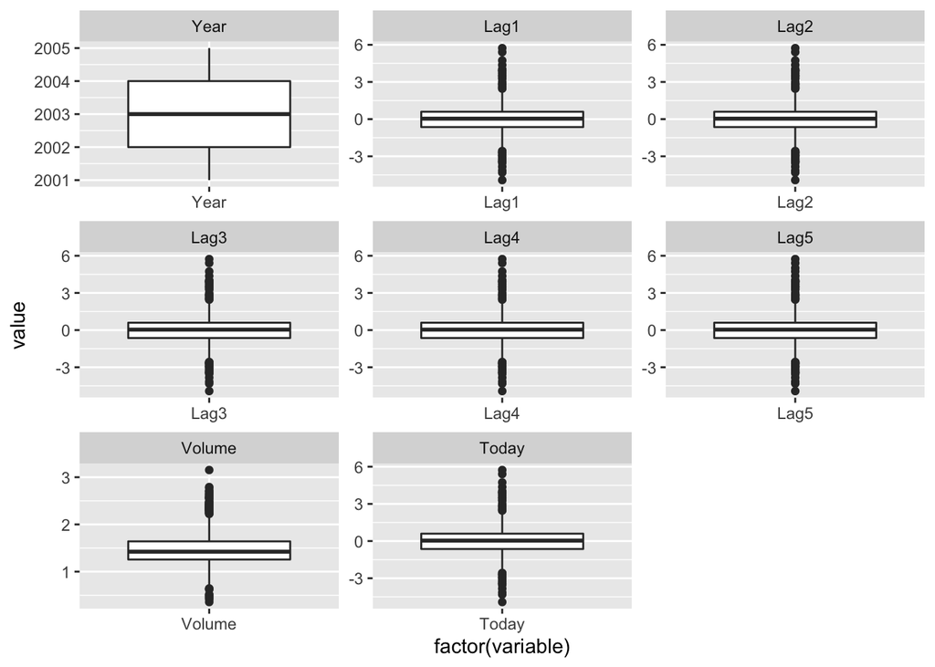

```r
par(mfrow = c(4,4))

library(dplyr)
market <- Smarket
market <- market%>%
  mutate(Direction=case_when(
    Direction=="Up" ~ 1,
    Direction=="Down" ~ 0,
  ))
library(reshape)
library(ggplot2)
meltData <- melt(Smarket)
p <- ggplot(meltData, aes(factor(variable), value))
p + geom_boxplot() + facet_wrap(~variable, scale="free")
```

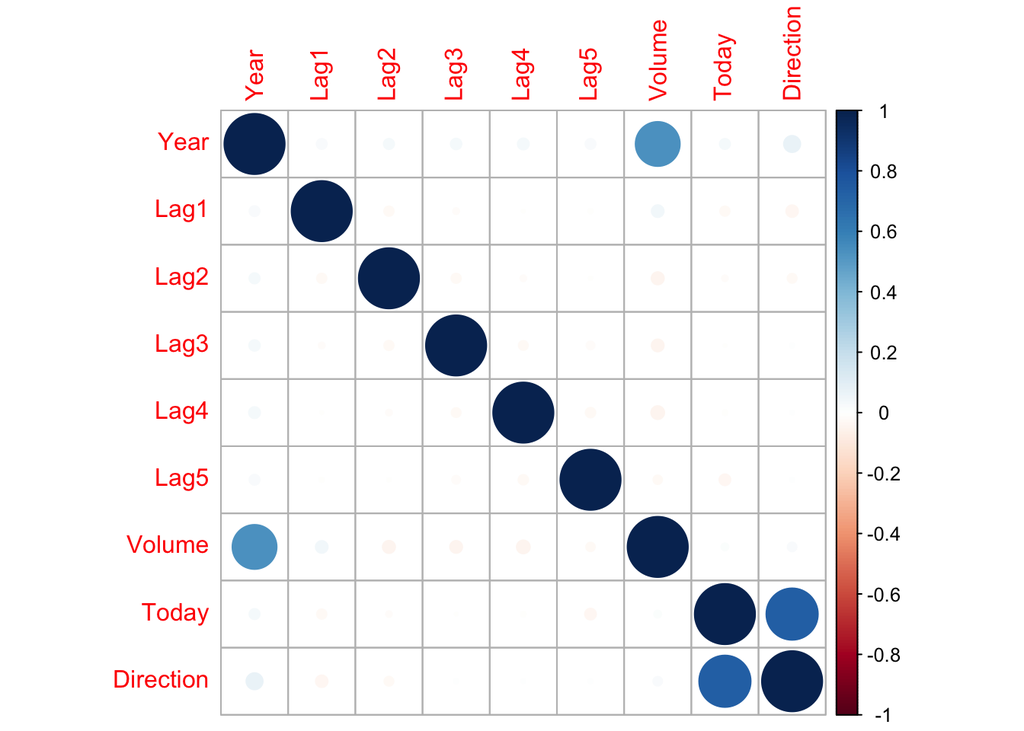

```r
cor2 <- cor(market)
corrplot(cor2)
```

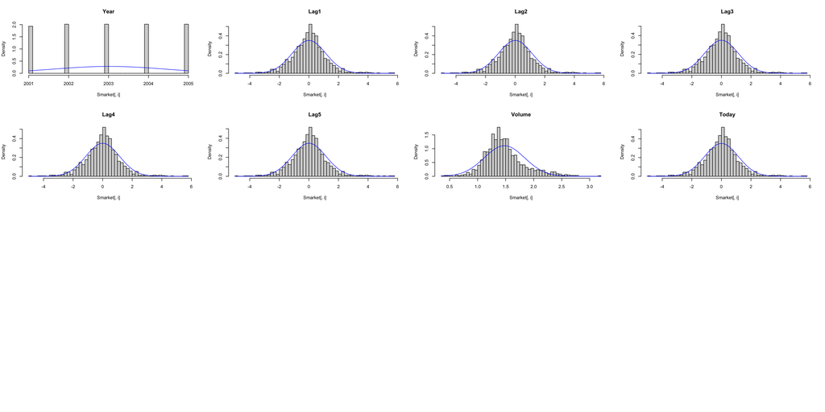

```r
par(mfrow = c(4,4))
for(i in 1:8) {
  fit <- fitdistr(Smarket[,i], densfun="normal")
  hist(Smarket[,i], pch=30, breaks=40, prob = TRUE, main = names(Smarket)[i])
  curve(dnorm(x, fit$estimate[1], fit$estimate[2]), col="blue", add=T)
}
```

For the year variable, data is collected from 2001 to 2005. Each day has an approximate median 0.04% return, with a maximum of a 5.7% return and a minimum of a -4.9% return. The median volume for a trading day is approximately 1.4 billion shares with a high of 3.1 billion and a low of 0.4 billion. The market had a positive return for 52% of the days. All lag variables have similar values as they contain the same data just offset by a number of days. The fitted distribution/histograms seem to have a very smooth normal data trend as expected. From the correlation plot, it can be seen that the volume and the year have a strong correlation. Direction is weakly correlated with the first 2 lags, year and volume.

```r
ols.mod <- lm(Direction ~ Lag1 + Lag2 +Lag3 + Lag4 + Lag5, data = market)
summary(ols.mod)
```

```
##
## Call:
## lm(formula = Direction ~ Lag1 + Lag2 + Lag3 + Lag4 + Lag5, data = market)
##
## Residuals:
##     Min      1Q  Median      3Q     Max
## -0.6133 -0.5156  0.4362  0.4809  0.5968
##
## Coefficients:
##              Estimate Std. Error t value Pr(>|t|)
## (Intercept)  0.518491   0.014151  36.640   <2e-16 ***
## Lag1        -0.017734   0.012464  -1.423    0.155
## Lag2        -0.010972   0.012468  -0.880    0.379
## Lag3         0.002304   0.012443   0.185    0.853
## Lag4         0.001797   0.012440   0.144    0.885
## Lag5         0.002315   0.012343   0.188    0.851
## ---
## Signif. codes:  0 '***' 0.001 '**' 0.01 '*' 0.05 '.' 0.1 ' ' 1
##
## Residual standard error: 0.5003 on 1244 degrees of freedom
## Multiple R-squared:  0.002282,   Adjusted R-squared:  -0.001728
## F-statistic: 0.569 on 5 and 1244 DF,  p-value: 0.7239
```

```r
ols.pred.classes <- ifelse(fitted(ols.mod) > 0.5, 1, 0)
table(ols.pred.classes, market$Direction)
```

```
##
## ols.pred.classes   0   1
##                0 114  98
##                1 488 550
```

```r
mean(ols.pred.classes == market$Direction)
```

```
## [1] 0.5312
```

```r
probit.mod = glm(Direction ~ Lag1 + Lag2 +Lag3 + Lag4 + Lag5, family=binomial(link="probit"),
                 data=market)
summary(probit.mod)
```

```
##
## Call:
## glm(formula = Direction ~ Lag1 + Lag2 + Lag3 + Lag4 + Lag5, family = binomial(link = "probit"),
##     data = market)
##
## Deviance Residuals:
##    Min      1Q  Median      3Q     Max
## -1.376  -1.204   1.071   1.145   1.346
##
## Coefficients:
##              Estimate Std. Error z value Pr(>|z|)
## (Intercept)  0.046441   0.035487   1.309    0.191
## Lag1        -0.044552   0.031323  -1.422    0.155
## Lag2        -0.027528   0.031299  -0.880    0.379
## Lag3         0.005709   0.031220   0.183    0.855
## Lag4         0.004606   0.031224   0.148    0.883
## Lag5         0.005825   0.030974   0.188    0.851
##
## (Dispersion parameter for binomial family taken to be 1)
##
##     Null deviance: 1731.2  on 1249  degrees of freedom
## Residual deviance: 1728.3  on 1244  degrees of freedom
## AIC: 1740.3
##
## Number of Fisher Scoring iterations: 3
```

```r
probit.pred.classes <- ifelse(fitted(probit.mod) > 0.5, 1, 0)
table(probit.pred.classes, market$Direction)
```

```
##
## probit.pred.classes   0   1
##                   0 113  98
##                   1 489 550
```

```r
mean(probit.pred.classes == market$Direction)
```

```
## [1] 0.5304
```

```r
logit.mod = glm(Direction ~ Lag1 + Lag2 +Lag3 + Lag4 + Lag5, family=binomial(link="logit"),
                data=market)
summary(logit.mod)
```

```
##
## Call:
## glm(formula = Direction ~ Lag1 + Lag2 + Lag3 + Lag4 + Lag5, family = binomial(link = "logit"),
##     data = market)
##
## Deviance Residuals:
##    Min      1Q  Median      3Q     Max
## -1.376  -1.204   1.071   1.145   1.347
##
## Coefficients:
##              Estimate Std. Error z value Pr(>|z|)
## (Intercept)  0.074163   0.056674   1.309    0.191
## Lag1        -0.071325   0.050104  -1.424    0.155
## Lag2        -0.044136   0.050025  -0.882    0.378
## Lag3         0.009229   0.049879   0.185    0.853
## Lag4         0.007211   0.049898   0.145    0.885
## Lag5         0.009311   0.049490   0.188    0.851
##
## (Dispersion parameter for binomial family taken to be 1)
##
##     Null deviance: 1731.2  on 1249  degrees of freedom
## Residual deviance: 1728.3  on 1244  degrees of freedom
## AIC: 1740.3
##
## Number of Fisher Scoring iterations: 3
```

```r
logit.pred.classes <- ifelse(fitted(logit.mod) > 0.5, 1, 0)
table(logit.pred.classes, market$Direction)
```

```
##
## logit.pred.classes   0   1
##                  0 116  98
##                  1 486 550
```

```r
mean(logit.pred.classes == market$Direction)
```

```
## [1] 0.5328
```

In general, we prefer probit and logit over linear probability models when dealing with binary explanatory variables because of the S curve that keeps things bounded and we can use this threshold to predict binary choices (by observing if it crosses the threshold or not).

The logit model is the preferred model because when we evaluated each model’s predictions of whether the market would end up or down for the day, the logit got the most correct at 53.28% compared to the probit model which got 53.04% and the linear model which got 53.12% correct.

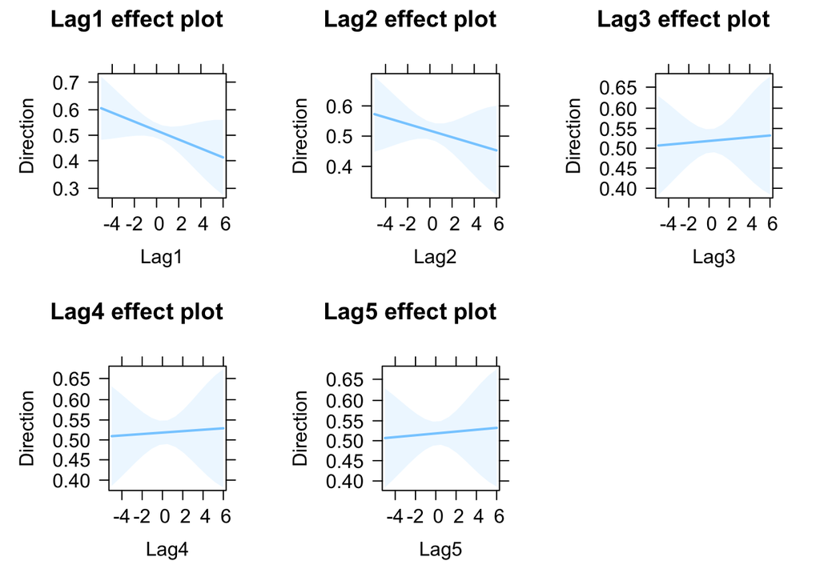

```r
library('effects')
nels.all <- allEffects(logit.mod)
plot(nels.all, style = 'stacked', colors = c('skyblue1', 'skyblue3', 'skyblue4'), rug = FALSE)
```

In terms of Effects plot, we see an interesting trend in the logit model where the first two lags seem to have a negative effect on the direction of the market while the other three have a positive, which suggests that at this time the market may be in a decline at least since the last two lags.

```r
library(caret)
inTraining <- createDataPartition(Smarket$Direction, p = .75, list = FALSE)
training <- Smarket[ inTraining,]
testing  <- Smarket[-inTraining,]
train_control <- trainControl(method = "cv",
                              number = 5)
logit_model1 <- train(as.factor(Direction) ~ Lag1 + Lag2 + Lag3 + Lag4 + Lag5 + Volume,
                     data = training,
                     method = "glm",
                     family = "binomial",
                     trControl = train_control)
pred_market1 <- predict(logit_model1, newdata = testing)
confusionMatrix(data=pred_market1, reference=as.factor(testing$Direction))
```

```
## Confusion Matrix and Statistics
##
##           Reference
## Prediction Down  Up
##       Down   36  41
##       Up    114 121
##
##                Accuracy : 0.5032
##                  95% CI : (0.4463, 0.56)
##     No Information Rate : 0.5192
##     P-Value [Acc > NIR] : 0.7335
##
##                   Kappa : -0.0133
##
##  Mcnemar's Test P-Value : 7.33e-09
##
##             Sensitivity : 0.2400
##             Specificity : 0.7469
##          Pos Pred Value : 0.4675
##          Neg Pred Value : 0.5149
##              Prevalence : 0.4808
##          Detection Rate : 0.1154
##    Detection Prevalence : 0.2468
##       Balanced Accuracy : 0.4935
##
##        'Positive' Class : Down
##
```

```r
logit_model2 <- train(as.factor(Direction) ~ Lag1 + Lag2 + Lag3 + Lag4 + Lag5,
                      data = training,
                      method = "glm",
                      family = "binomial",
                      trControl = train_control)
pred_market2 <- predict(logit_model2, newdata = testing)
confusionMatrix(data=pred_market2, reference=as.factor(testing$Direction))
```

```
## Confusion Matrix and Statistics
##
##           Reference
## Prediction Down  Up
##       Down   25  20
##       Up    125 142
##
##                Accuracy : 0.5353
##                  95% CI : (0.4782, 0.5916)
##     No Information Rate : 0.5192
##     P-Value [Acc > NIR] : 0.3053
##
##                   Kappa : 0.0444
##
##  Mcnemar's Test P-Value : <2e-16
##
##             Sensitivity : 0.16667
##             Specificity : 0.87654
##          Pos Pred Value : 0.55556
##          Neg Pred Value : 0.53184
##              Prevalence : 0.48077
##          Detection Rate : 0.08013
##    Detection Prevalence : 0.14423
##       Balanced Accuracy : 0.52160
##
##        'Positive' Class : Down
##
```

```r
logit_model3 <- train(as.factor(Direction) ~ Lag1 + Lag2 + Lag3 + Lag4,
                      data = training,
                      method = "glm",
                      family = "binomial",
                      trControl = train_control)
pred_market3 <- predict(logit_model3, newdata = testing)
confusionMatrix(data=pred_market3, reference=as.factor(testing$Direction))
```

```
## Confusion Matrix and Statistics
##
##           Reference
## Prediction Down  Up
##       Down   20  17
##       Up    130 145
##
##                Accuracy : 0.5288
##                  95% CI : (0.4718, 0.5853)
##     No Information Rate : 0.5192
##     P-Value [Acc > NIR] : 0.3888
##
##                   Kappa : 0.0292
##
##  Mcnemar's Test P-Value : <2e-16
##
##             Sensitivity : 0.1333
##             Specificity : 0.8951
##          Pos Pred Value : 0.5405
##          Neg Pred Value : 0.5273
##              Prevalence : 0.4808
##          Detection Rate : 0.0641
##    Detection Prevalence : 0.1186
##       Balanced Accuracy : 0.5142
##
##        'Positive' Class : Down
##
```

```r
logit_model4 <- train(as.factor(Direction) ~ Lag1 + Lag2 + Lag3,
                      data = training,
                      method = "glm",
                      family = "binomial",
                      trControl = train_control)
pred_market4 <- predict(logit_model4, newdata = testing)
confusionMatrix(data=pred_market4, reference=as.factor(testing$Direction))
```

```
## Confusion Matrix and Statistics
##
##           Reference
## Prediction Down  Up
##       Down   23  15
##       Up    127 147
##
##                Accuracy : 0.5449
##                  95% CI : (0.4878, 0.6011)
##     No Information Rate : 0.5192
##     P-Value [Acc > NIR] : 0.1978
##
##                   Kappa : 0.0625
##
##  Mcnemar's Test P-Value : <2e-16
##
##             Sensitivity : 0.15333
##             Specificity : 0.90741
##          Pos Pred Value : 0.60526
##          Neg Pred Value : 0.53650
##              Prevalence : 0.48077
##          Detection Rate : 0.07372
##    Detection Prevalence : 0.12179
##       Balanced Accuracy : 0.53037
##
##        'Positive' Class : Down
##
```